# Advertisemnt Dataset Analysis_R-Week1_IP

## Exploratory Data Analysis

## Univariate Analysis

```r
# displaying the summary statistics for the quantitative variables in my data frame

quantitative <- my_dataset[ ,c("Daily Internet Usage","Daily Time Spent on Site","Area Income","Age")]
summary(quantitative)
```

```
##  Daily Internet Usage Daily Time Spent on Site  Area Income         Age
##  Min.   :104.8        Min.   :32.60            Min.   :13996   Min.   :19.00
##  1st Qu.:138.8        1st Qu.:51.36            1st Qu.:47032   1st Qu.:29.00
##  Median :183.1        Median :68.22            Median :57012   Median :35.00
##  Mean   :180.0        Mean   :65.00            Mean   :55000   Mean   :36.01
##  3rd Qu.:218.8        3rd Qu.:78.55            3rd Qu.:65471   3rd Qu.:42.00
##  Max.   :270.0        Max.   :91.43            Max.   :79485   Max.   :61.00
```

```r
# displaying the counts for the number of people who clicked and didn't click the ads

clicked.on.ads <- my_dataset$`Clicked on Ad`

plotted_numbers <- table(clicked.on.ads)
plotted_numbers
```

```
## clicked.on.ads
##   0   1
## 500 500
```

There is an equal number of people in the data frame for both categories; those who clicked and those who didn’t click on the ad.

### Bi variate Analysis

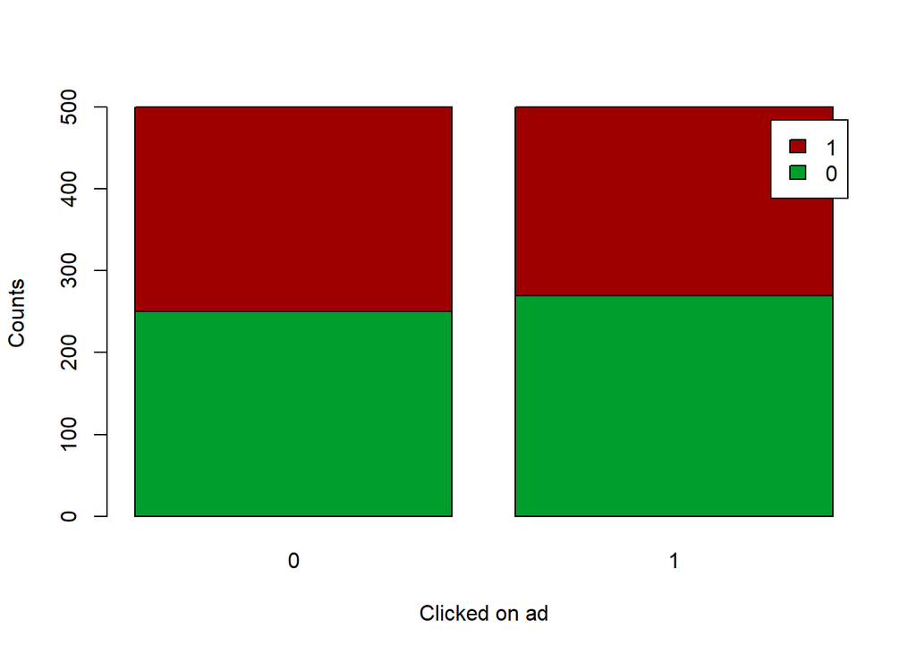

```r
# plotting the numbers by gender for those who clicked and those who didn't click on the ad
by_gender <- my_dataset[ ,c("Male","Clicked on Ad")]

barplot(table(by_gender),
        legend.text = TRUE,
        xlab = "Clicked on ad",
        ylab = "Counts",
        col = c("#009E2D","#9E0000"),
        )
```

The difference in numbers of males for those who clicked and did not click on ads is very small. Gender might not be a very good determinant.

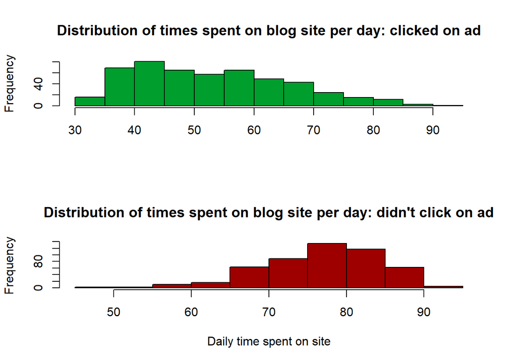

```r
# displaying the distribution of the daily time spent on site data column

# setting the parameter specifying that my vizs should appear in two rows, one for each class in the clicked on ad variable.
par(mfrow = c(2,1))

# plotting my histograms
hist(my_dataset$`Daily Time Spent on Site`[my_dataset$`Clicked on Ad`==1],
     col = '#009E2D',
     breaks = 12,
     xlab = "",
     main = "Distribution of times spent on blog site per day: clicked on ad")

hist(my_dataset$`Daily Time Spent on Site`[my_dataset$`Clicked on Ad`==0],
     col = '#9E0000',
     breaks = 12,
     xlab = "Daily time spent on site",
     main = "Distribution of times spent on blog site per day: didn't click on ad")
```

For the individuals that clicked on the ad, the distribution indicates a majority spent around 40 to 60 minutes on the site. For the individuals that did not click the ad, the distribution indicates that a majority spent around 70 to 85 minutes on the site. This is way more than that of those that did click the ad.

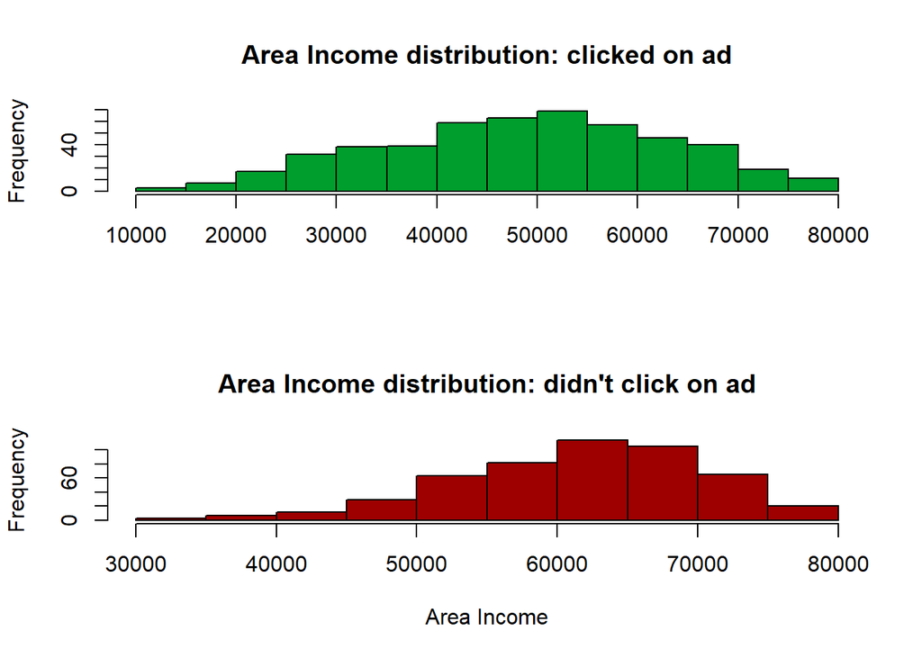

```r
# displaying the area income distribution

par(mfrow = c(2,1))
hist(my_dataset$`Area Income`[my_dataset$`Clicked on Ad` == 1],
     col = '#009E2D',
     breaks = 12,
     xlab = "",
     main = "Area Income distribution: clicked on ad")

hist(my_dataset$`Area Income`[my_dataset$`Clicked on Ad` == 0],
     col = '#9E0000',
     breaks = 12,
     xlab = "Area Income",
     main = "Area Income distribution: didn't click on ad")
```

The area income distribution for the those that clicked and didn’t click the add is somewhat similar. The area income distribution for those that didn’t click on the ad, however, have a relatively higher frequencies between 60000 to 70000.

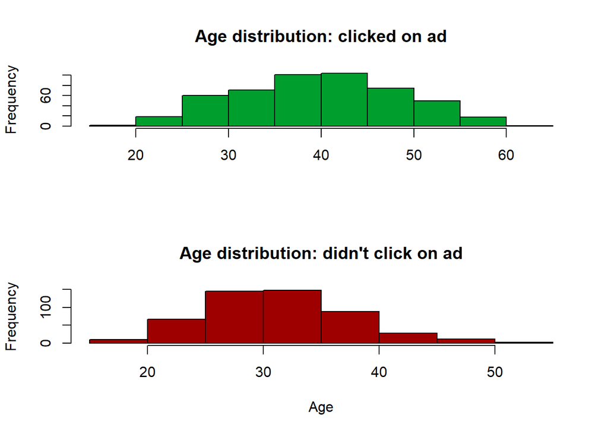

```r
# plotting the age distribution of the individuals in the data

par(mfrow = c(2,1))
hist(my_dataset$Age[my_dataset$`Clicked on Ad` == 1],
     breaks = 12,
     col = '#009E2D',
     xlab = "",
     main = "Age distribution: clicked on ad")

hist(my_dataset$Age[my_dataset$`Clicked on Ad` == 0],
     breaks = 12,
     col = '#9E0000',
     xlab = "Age",
     main = "Age distribution: didn't click on ad")
```

The age distribution for the individuals that didn’t click an ad appears to contain less individuals in their 50s and 60s.A majority of these individuals are in their late 20s and early 30s. The shapes of the two distributions is similar. A majority of individuals that clicked the ad are in their 40s and and late 30s.

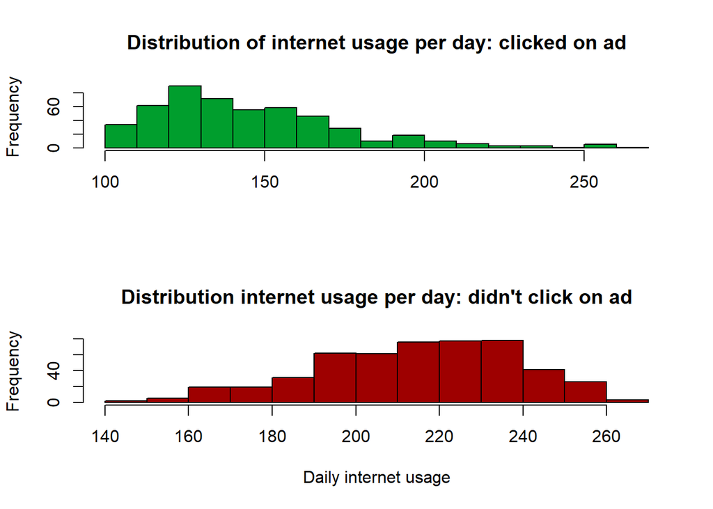

```r
# displaying the distribution of the daily time spent on site data column
par(mfrow = c(2,1))
hist(my_dataset$`Daily Internet Usage`[my_dataset$`Clicked on Ad`==1],
     col = '#009E2D',
     breaks = 12,
     xlab = "",
     main = "Distribution of internet usage per day: clicked on ad")

hist(my_dataset$`Daily Internet Usage`[my_dataset$`Clicked on Ad`==0],
     col = '#9E0000',
     breaks = 12,
     xlab = "Daily internet usage",
     main = "Distribution internet usage per day: didn't click on ad")
```

It is evident that the individuals that clicked on the ad used less internet per day in comparison to those that didn’t click the ad.

```r
library(dplyr)
# displaying the top ten countries with highest number of people having clicked on the ad.

countries <- my_dataset[, c('Country', "Clicked on Ad")]
Countries = table(countries)
Countries <- as.data.frame(Countries)


clicked <- filter(Countries, Clicked.on.Ad==1)
# ordering in terms of frequency

sorted_clicked <- arrange(clicked, desc(Freq))
head(sorted_clicked, 10)
```

```
##          Country Clicked.on.Ad Freq
## 1      Australia             1    7
## 2       Ethiopia             1    7
## 3         Turkey             1    7
## 4        Liberia             1    6
## 5  Liechtenstein             1    6
## 6   South Africa             1    6
## 7    Afghanistan             1    5
## 8         France             1    5
## 9        Hungary             1    5
## 10       Mayotte             1    5
```

```r
# displaying the top twenty topics visited on the blog site

topics <- my_dataset[, c('Ad Topic Line', "Clicked on Ad")]
Topics <- table(topics)
Topics <- as.data.frame(Topics)

clicked_ad <- filter(Topics, Clicked.on.Ad == 1)

# ordering in terms of frequency

sorted <- arrange(clicked_ad, desc(Freq))
head(sorted, 20)
```

```
##                                  Ad.Topic.Line Clicked.on.Ad Freq
## 1               Adaptive asynchronous attitude             1    1
## 2       Adaptive context-sensitive application             1    1
## 3      Adaptive contextually-based methodology             1    1
## 4         Adaptive demand-driven knowledgebase             1    1
## 5                  Adaptive uniform capability             1    1
## 6                   Advanced 24/7 productivity             1    1
## 7      Advanced disintermediate data-warehouse             1    1
## 8               Advanced systemic productivity             1    1
## 9         Advanced web-enabled standardization             1    1
## 10 Ameliorated bandwidth-monitored contingency             1    1
## 11          Ameliorated client-driven forecast             1    1
## 12      Ameliorated coherent open architecture             1    1
## 13               Ameliorated discrete extranet             1    1
## 14                Ameliorated exuding solution             1    1
## 15           Ameliorated leadingedge help-desk             1    1
## 16       Ameliorated well-modulated complexity             1    1
## 17              Assimilated fault-tolerant hub             1    1
## 18            Assimilated multi-state paradigm             1    1
## 19        Assimilated next generation firmware             1    1
## 20       Automated client-driven orchestration             1    1
```

The topic with the highest frequency only had one visitor. All top twenty topics had a single visitor that clicked the ad.No significant inference could be obtained in relation to determining if an individual would click an ad or not.

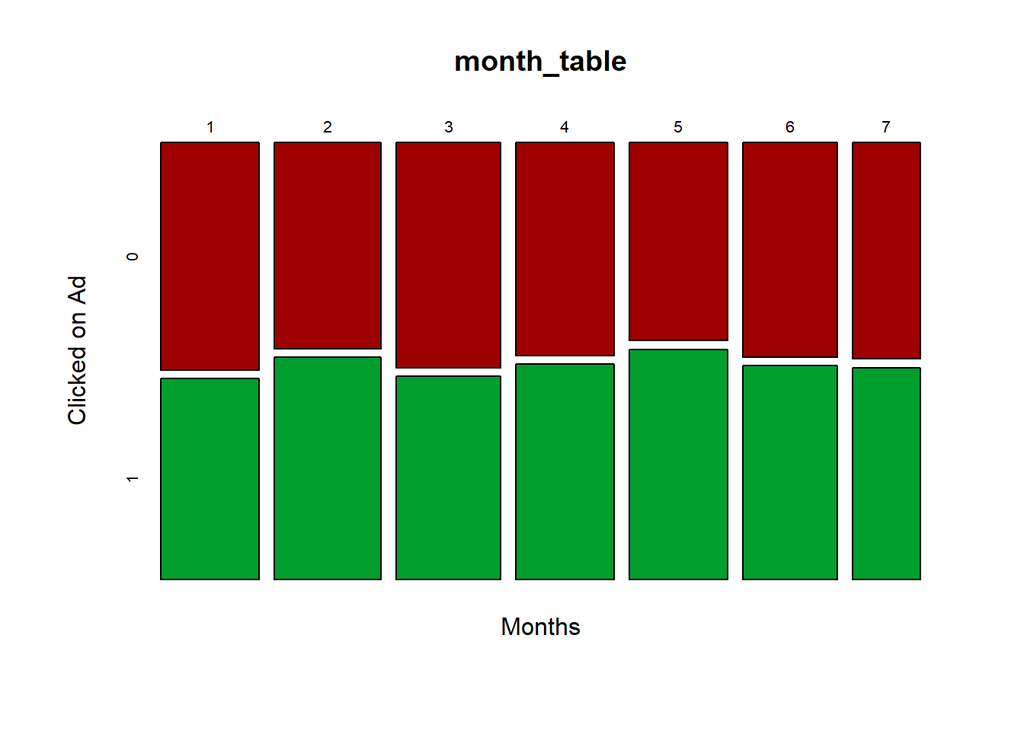

```r
m <- my_dataset[ , c("month", "Clicked on Ad")]
month_table <- table(m)

plot(month_table,
     xlab = "Months",
     col = c("#9E0000","#009E2D"),
     ylab = "Clicked on Ad"
     )
```

There is no significant difference in numbers across the months for the two classes; those who clicked and those who didn’t click the ad.

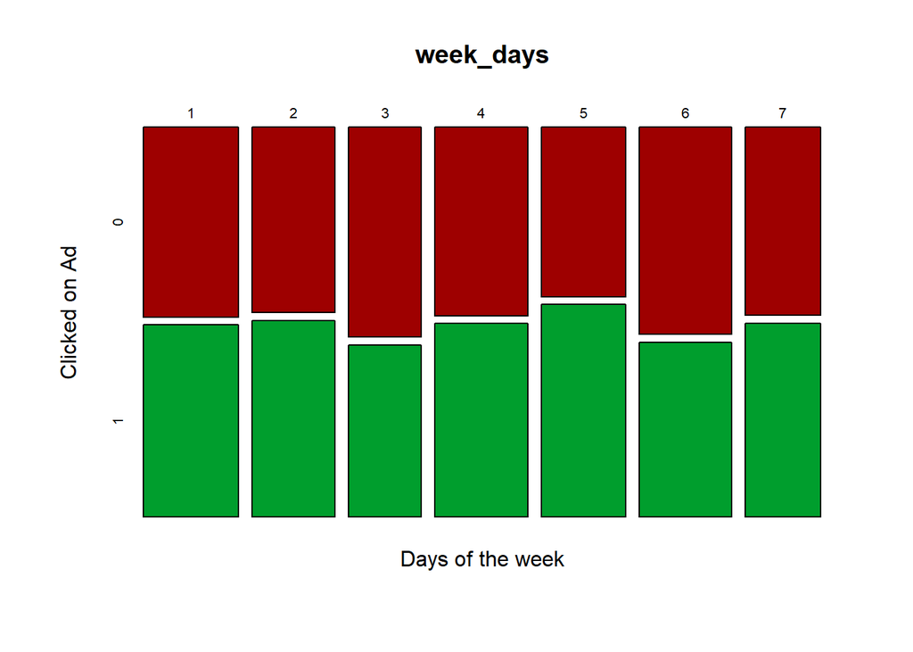

```r
day.week <- my_dataset[ , c("Day.of.week","Clicked on Ad")]
week_days <- table(day.week)

plot(week_days,
     xlab = "Days of the week",
     col = c("#9E0000","#009E2D"),
     ylab = "Clicked on Ad"
     )
```

A similar case is exhibited for the days of the week as the months, no significant difference in numbers takes place across the different days of the week for either classes.

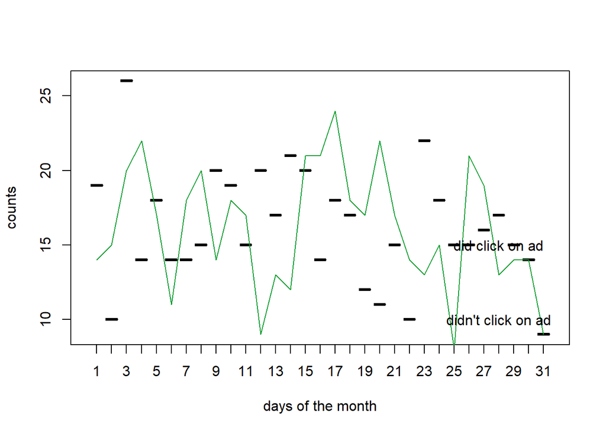

```r
library(dplyr)
days_ <- my_dataset[ ,c("day", "Clicked on Ad")]

days_df <- table(days_)
days_df <- as.data.frame(days_df)

did_click <- filter(days_df, Clicked.on.Ad == 1)
didnt_click <- filter(days_df, Clicked.on.Ad == 0)

plot(did_click$day, did_click$Freq, type = "l", col = "#9E0000", xlab = "days of the month", ylab = "counts")
lines(didnt_click$day, didnt_click$Freq, type = "l", col = "#009E2D")
text(x=28, y=c(15,10), labels=c("did click on ad", "didn't click on ad"))
```

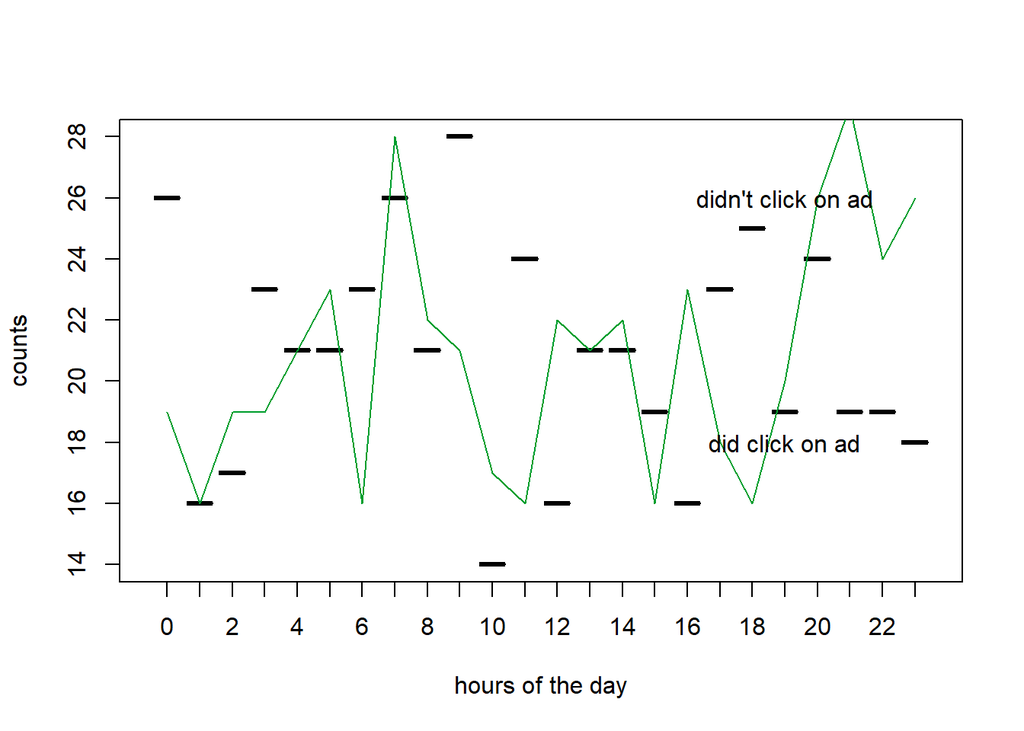

```r
# plotting the frequencies of individuals on the blog site during the different hours of the Day.

hours <- my_dataset[ ,c("hour", "Clicked on Ad")]
Hours <- table(hours)
Hour <- as.data.frame(Hours)


did_click_h <- filter(Hour, Clicked.on.Ad == 1)
didnt_click_h <- filter(Hour, Clicked.on.Ad == 0)

plot(did_click_h$hour, did_click_h$Freq, type="l", col="#9E0000", xlab="hours of the day", ylab="counts")
lines(didnt_click_h$hour, didnt_click_h$Freq, type ="l", col = "#009E2D")
text(x=20, y=c(18,26), labels=c("did click on ad", "didn't click on ad"))
```

### Multivariate Analysis

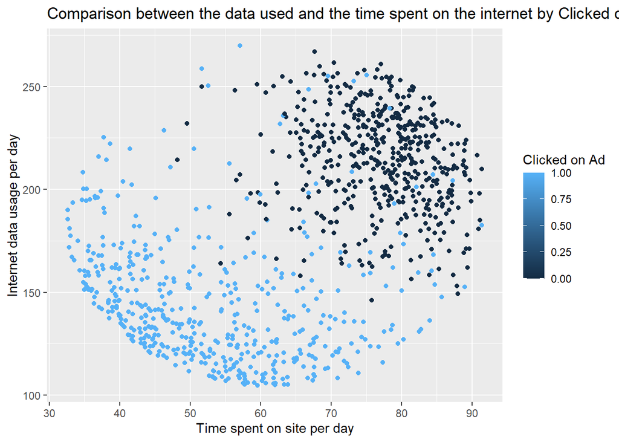

```r
library(ggplot2)
qplot(`Daily Time Spent on Site`,
      `Daily Internet Usage`,
      data = my_dataset,
      colour = `Clicked on Ad`,
      xlab = "Time spent on site per day",
      ylab = "Internet data usage per day",
      main = "Comparison between the data used and the time spent on the internet by Clicked on ad variable")
```

Data points exhibiting higher internet usage and time spent on the site per day are less likely to have clicked on the ad. The two classes of data points are distinctly separated.

```r
# displaying the correlation coefficients for the variables in my data frame

cor(my_dataset[ ,c("Daily Time Spent on Site", "Daily Internet Usage", "Age", "Male", "Area Income", "Clicked on Ad")])
```

```
##                          Daily Time Spent on Site Daily Internet Usage
## Daily Time Spent on Site               1.00000000           0.51865848
## Daily Internet Usage                   0.51865848           1.00000000
## Age                                   -0.33151334          -0.36720856
## Male                                  -0.01895085           0.02801233
## Area Income                            0.31095441           0.33749553
## Clicked on Ad                         -0.74811656          -0.78653918
##                                  Age         Male  Area Income Clicked on Ad
## Daily Time Spent on Site -0.33151334 -0.018950855  0.310954413   -0.74811656
## Daily Internet Usage     -0.36720856  0.028012326  0.337495533   -0.78653918
## Age                       1.00000000 -0.021044064 -0.182604955    0.49253127
## Male                     -0.02104406  1.000000000  0.001322359   -0.03802747
## Area Income              -0.18260496  0.001322359  1.000000000   -0.47625463
## Clicked on Ad             0.49253127 -0.038027466 -0.476254628    1.00000000
```

The variable with the highest coefficient is Daily internet usage closely followed by Daily time spent on site. The gender coefficient is very low meaning the variable cannot be reliably used to determine whether an individual would click on an add or not. The area income and age variable coefficients indicate that the variables can effect a change in the clicked.on.ad variable but not that much. The variables cannot be reliably used to determine whether an individual would click on an ad or not.